# Supervised Learning - Foundations Project: ReCell

## Data Preprocessing

- Missing value treatment
- Feature engineering (if needed)
- Outlier detection and treatment (if needed)
- Preparing data for modeling
- Any other preprocessing steps (if needed)

```python
# As above, we should look at the missing values
df.isnull().sum()
```

```
brand_name                 0
os                         0
screen_size                0
4g                         0
5g                         0
main_camera_mp           179
selfie_camera_mp           2
int_memory                 4
ram                        4
battery                    6
weight                     7
release_year               0
days_used                  0
normalized_used_price      0
normalized_new_price       0
dtype: int64
```

```python
#let's make a copy first
data=df.copy()
```

```python
# main_camera_mp, selfie_camera_mp, int_memory, ram, battery, weight
# To fill in those missing values, instead of deleting it
# let's look at the median of each brand name will be replaced for NaN
columns_to_use=["main_camera_mp", "selfie_camera_mp", "int_memory", "ram", "battery", "weight"]
```

```python
# Use this replace NaN
for column in columns_to_use:
    data[column]=data[column].astype(float)
    data[column]=data[column].fillna(value=data.groupby(['brand_name','release_year'])[column].transform('median'))

data.isnull().sum()
# The missing value comes from the particular NaN in each brand, release year
```

```
brand_name                 0
os                         0
screen_size                0
4g                         0
5g                         0
main_camera_mp           179
selfie_camera_mp           2
int_memory                 0
ram                        0
battery                    6
weight                     7
release_year               0
days_used                  0
normalized_used_price      0
normalized_new_price       0
dtype: int64
```

```python
# Others, we will use brand_name only
another_col = ['main_camera_mp','selfie_camera_mp','battery','weight']
```

```python
# Use this replace NaN
for column in another_col:
    data[column]=data[column].astype(float)
    data[column]=data[column].fillna(value=data.groupby(['brand_name'])[column].transform('median'))

data.isnull().sum()
# Another 10 missing values in main_Camera_mp
```

```
brand_name                0
os                        0
screen_size               0
4g                        0
5g                        0
main_camera_mp           10
selfie_camera_mp          0
int_memory                0
ram                       0
battery                   0
weight                    0
release_year              0
days_used                 0
normalized_used_price     0
normalized_new_price      0
dtype: int64
```

```python
# We will use the following column to fill it up
data['main_camera_mp']=data['main_camera_mp'].fillna(value=data['main_camera_mp'].median())
data.isnull().sum()
# Zero missing values!
```

```
brand_name               0
os                       0
screen_size              0
4g                       0
5g                       0
main_camera_mp           0
selfie_camera_mp         0
int_memory               0
ram                      0
battery                  0
weight                   0
release_year             0
days_used                0
normalized_used_price    0
normalized_new_price     0
dtype: int64
```

#### **Outlier detection and treatment**

```python
# Outlier detection
numerical_column=data.select_dtypes(include=np.number).columns.tolist()
numerical_column
```

```
['screen_size',
 'main_camera_mp',
 'selfie_camera_mp',
 'int_memory',
 'ram',
 'battery',
 'weight',
 'release_year',
 'days_used',
 'normalized_used_price',
 'normalized_new_price']
```

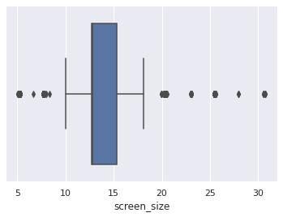

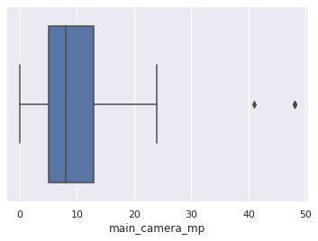

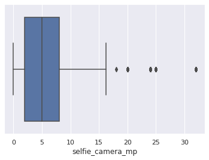

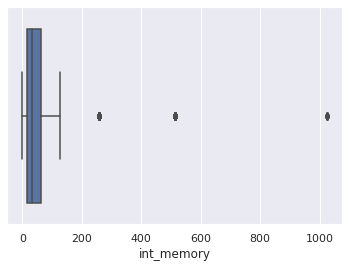

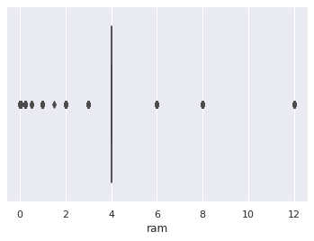

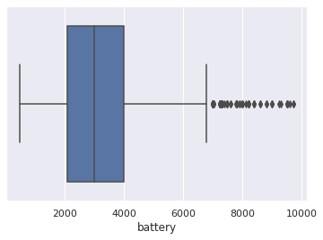

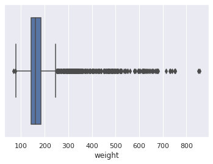

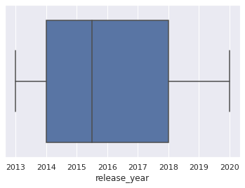

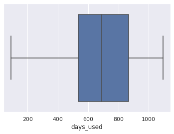

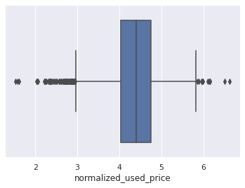

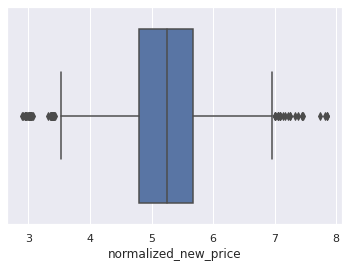

```python
for column in numerical_column:
    x = sns.boxplot(data=data, x=column);
    plt.show()
# There are outliers, but I won't be droping
# or replacing them, because that could alter the whole purpose
# of this project
```

**Preparing data for modeling**

```python
# Split independent(x) & dependent(y) variable
# In this case, y would be 'normalized_used_price'
X=data.drop("normalized_used_price", axis=1)
y=data["normalized_used_price"]
print(X.head())
```

```
  brand_name       os  screen_size   4g   5g  main_camera_mp  \
0      Honor  Android        14.50  yes   no            13.0
1      Honor  Android        17.30  yes  yes            13.0
2      Honor  Android        16.69  yes  yes            13.0
3      Honor  Android        25.50  yes  yes            13.0
4      Honor  Android        15.32  yes   no            13.0

   selfie_camera_mp  int_memory  ram  battery  weight  release_year  \
0               5.0        64.0  3.0   3020.0   146.0          2020
1              16.0       128.0  8.0   4300.0   213.0          2020
2               8.0       128.0  8.0   4200.0   213.0          2020
3               8.0        64.0  6.0   7250.0   480.0          2020
4               8.0        64.0  3.0   5000.0   185.0          2020

   days_used  normalized_new_price
0        127              4.715100
1        325              5.519018
2        162              5.884631
3        345              5.630961
4        293              4.947837
```

```python
y.head()
```

```
0    4.307572
1    5.162097
2    5.111084
3    5.135387
4    4.389995
Name: normalized_used_price, dtype: float64
```

```python
# add constant term to the data
X=sm.add_constant(X)
```

```python
X=pd.get_dummies(X, columns=X.select_dtypes(include=["object","category"]).columns.tolist(),drop_first=True)
X.head()
# We added a constant (const),and encoded categorical variables(brand_name, os, 4g, 5g)
```

|  | const | screen_size | main_camera_mp | selfie_camera_mp | int_memory | ram | battery | weight | release_year | days_used | ... | brand_name_Spice | brand_name_Vivo | brand_name_XOLO | brand_name_Xiaomi | brand_name_ZTE | os_Others | os_Windows | os_iOS | 4g_yes | 5g_yes |
| --- | --- | --- | --- | --- | --- | --- | --- | --- | --- | --- | --- | --- | --- | --- | --- | --- | --- | --- | --- | --- | --- |
| 0 | 1.0 | 14.50 | 13.0 | 5.0 | 64.0 | 3.0 | 3020.0 | 146.0 | 2020 | 127 | ... | 0 | 0 | 0 | 0 | 0 | 0 | 0 | 0 | 1 | 0 |
| 1 | 1.0 | 17.30 | 13.0 | 16.0 | 128.0 | 8.0 | 4300.0 | 213.0 | 2020 | 325 | ... | 0 | 0 | 0 | 0 | 0 | 0 | 0 | 0 | 1 | 1 |
| 2 | 1.0 | 16.69 | 13.0 | 8.0 | 128.0 | 8.0 | 4200.0 | 213.0 | 2020 | 162 | ... | 0 | 0 | 0 | 0 | 0 | 0 | 0 | 0 | 1 | 1 |
| 3 | 1.0 | 25.50 | 13.0 | 8.0 | 64.0 | 6.0 | 7250.0 | 480.0 | 2020 | 345 | ... | 0 | 0 | 0 | 0 | 0 | 0 | 0 | 0 | 1 | 1 |
| 4 | 1.0 | 15.32 | 13.0 | 8.0 | 64.0 | 3.0 | 5000.0 | 185.0 | 2020 | 293 | ... | 0 | 0 | 0 | 0 | 0 | 0 | 0 | 0 | 1 | 0 |

5 rows × 49 columns

```python
# Then we will divide them into train & test data
# Each with ratio train (70) test (30)
X_train, X_test, y_train, y_test = train_test_split(X,y,test_size=0.30, random_state=1)
```

```python
X_train.shape
# 2417 rows of train data
```

```
(2417, 49)
```

```python
X_test.shape
# 1037 rows of test data
```

```
(1037, 49)
```

```python
X.shape
# train + test equals total (3454)
```

```
(3454, 49)
```

## Model Building - Linear Regression

Use statsmodel OLS Regression Results to make linear model

```python
model = sm.OLS(y_train, X_train).fit()
print(model.summary())
```

```
                              OLS Regression Results
=================================================================================
Dep. Variable:     normalized_used_price   R-squared:                       0.845
Model:                               OLS   Adj. R-squared:                  0.842
Method:                    Least Squares   F-statistic:                     268.7
Date:                   Wed, 20 Jul 2022   Prob (F-statistic):               0.00
Time:                           19:17:19   Log-Likelihood:                 123.85
No. Observations:                   2417   AIC:                            -149.7
Df Residuals:                       2368   BIC:                             134.0
Df Model:                             48
Covariance Type:               nonrobust
=========================================================================================
                            coef    std err          t      P>|t|      [0.025      0.975]
-----------------------------------------------------------------------------------------
const                   -46.5094      9.199     -5.056      0.000     -64.548     -28.471
screen_size               0.0244      0.003      7.163      0.000       0.018       0.031
main_camera_mp            0.0208      0.002     13.848      0.000       0.018       0.024
selfie_camera_mp          0.0135      0.001     11.997      0.000       0.011       0.016
int_memory                0.0001   6.97e-05      1.651      0.099   -2.16e-05       0.000
ram                       0.0230      0.005      4.451      0.000       0.013       0.033
battery               -1.689e-05   7.27e-06     -2.321      0.020   -3.12e-05   -2.62e-06
weight                    0.0010      0.000      7.480      0.000       0.001       0.001
release_year              0.0237      0.005      5.193      0.000       0.015       0.033
days_used              4.216e-05   3.09e-05      1.366      0.172   -1.84e-05       0.000
normalized_new_price      0.4311      0.012     35.147      0.000       0.407       0.455
brand_name_Alcatel        0.0154      0.048      0.323      0.747      -0.078       0.109
brand_name_Apple         -0.0038      0.147     -0.026      0.980      -0.292       0.285
brand_name_Asus           0.0151      0.048      0.314      0.753      -0.079       0.109
brand_name_BlackBerry    -0.0300      0.070     -0.427      0.669      -0.168       0.108
brand_name_Celkon        -0.0468      0.066     -0.707      0.480      -0.177       0.083
brand_name_Coolpad        0.0209      0.073      0.287      0.774      -0.122       0.164
brand_name_Gionee         0.0448      0.058      0.775      0.438      -0.068       0.158
brand_name_Google        -0.0326      0.085     -0.385      0.700      -0.199       0.133
brand_name_HTC           -0.0130      0.048     -0.270      0.787      -0.108       0.081
brand_name_Honor          0.0317      0.049      0.644      0.520      -0.065       0.128
brand_name_Huawei        -0.0020      0.044     -0.046      0.964      -0.089       0.085
brand_name_Infinix        0.1633      0.093      1.752      0.080      -0.019       0.346
brand_name_Karbonn        0.0943      0.067      1.405      0.160      -0.037       0.226
brand_name_LG            -0.0132      0.045     -0.291      0.771      -0.102       0.076
brand_name_Lava           0.0332      0.062      0.533      0.594      -0.089       0.155
```

[output cut: 19 more lines]

```
os_Windows               -0.0207      0.045     -0.459      0.646      -0.109       0.068
os_iOS                   -0.0663      0.146     -0.453      0.651      -0.354       0.221
4g_yes                    0.0528      0.016      3.326      0.001       0.022       0.084
5g_yes                   -0.0714      0.031     -2.268      0.023      -0.133      -0.010
==============================================================================
Omnibus:                      223.612   Durbin-Watson:                   1.910
Prob(Omnibus):                  0.000   Jarque-Bera (JB):              422.275
Skew:                          -0.620   Prob(JB):                     2.01e-92
Kurtosis:                       4.630   Cond. No.                     7.70e+06
==============================================================================

Warnings:
[1] Standard Errors assume that the covariance matrix of the errors is correctly specified.
[2] The condition number is large, 7.7e+06. This might indicate that there are
strong multicollinearity or other numerical problems.
```

## Model Performance Check

Let's check the followings:

MSE, RMSE, MAE, MAPE, Rsquared, adjusted Rquared for training set (70%)

```python
# MSE & RMSE
MSE = mean_squared_error(y_train, model.predict(X_train))
print("MSE is", MSE)
RMSE = np.sqrt(mean_squared_error(y_train, model.predict(X_train)))
print("RMSE is", RMSE)
```

```
MSE is 0.052846562412173885
RMSE is 0.22988380197868202
```

```python
# MAE & MAPE
MAE = mean_absolute_error(y_train,model.predict(X_train))
print("MAE is", MAE)
MAPE = np.mean(np.abs(y_train-model.predict(X_train))/y_train*100)
print("MAPE is", MAPE)
```

```
MAE is 0.18032615182768724
MAPE is 4.3268410678246445
```

```python
# R-squared & Adjusted R-squared
r2=r2_score(y_train, model.predict(X_train))
print("R-squared is",r2)
n=X_train.shape[0]
k=X_train.shape[1]
ad_r2=(1-((1-r2)*(n-1)/(n-k-1)))
print("Adjusted R-squared is",ad_r2)
```

```
R-squared is 0.8448860078512485
Adjusted R-squared is 0.8416749450648991
```

```python
# Let's make a dictionary to organize the train data
dataframe=pd.DataFrame({"MSE":MSE,"RMSE":RMSE, "MAE":MAE, "MAPE": MAPE, "R2":r2,"Adjusted_R2":ad_r2 },index=[0])
dataframe
```

|  | MSE | RMSE | MAE | MAPE | R2 | Adjusted_R2 |
| --- | --- | --- | --- | --- | --- | --- |
| 0 | 0.052847 | 0.229884 | 0.180326 | 4.326841 | 0.844886 | 0.841675 |

MSE, RMSE, MAE, MAPE, Rsquared, adjusted Rquared for test set (30%)

```python
# MSE & RMSE
MSE = mean_squared_error(y_test, model.predict(X_test))
print("MSE is", MSE)
RMSE = np.sqrt(mean_squared_error(y_test, model.predict(X_test)))
print("RMSE is", RMSE)
```

```
MSE is 0.0568144857533261
RMSE is 0.23835789425426232
```

```python
# MAE & MAPE
MAE = mean_absolute_error(y_test,model.predict(X_test))
print("MAE is", MAE)
MAPE = np.mean(np.abs(y_test-model.predict(X_test))/y_test*100)
print("MAPE is", MAPE)
```

```
MAE is 0.18474900805179023
MAPE is 4.501651065162255
```

```python
# R-squared & Adjusted R-squared
r2=r2_score(y_test, model.predict(X_test))
print("R-squared is",r2)
n=X_test.shape[0]
k=X_test.shape[1]
ad_r2=(1-((1-r2)*(n-1)/(n-k-1)))
print("Adjusted R-squared is",ad_r2)
```

```
R-squared is 0.8424791238858964
Adjusted R-squared is 0.8346589385468983
```

```python
# Let's make a dictionary to organize the data for test data
dataframe=pd.DataFrame({"MSE":MSE,"RMSE":RMSE, "MAE":MAE, "MAPE": MAPE, "R2":r2,"Adjusted_R2":ad_r2 },index=[0])
dataframe
```

|  | MSE | RMSE | MAE | MAPE | R2 | Adjusted_R2 |
| --- | --- | --- | --- | --- | --- | --- |
| 0 | 0.056814 | 0.238358 | 0.184749 | 4.501651 | 0.842479 | 0.834659 |

## Checking Linear Regression Assumptions

- In order to make statistical inferences from a linear regression model, it is important to ensure that the assumptions of linear regression are satisfied.
- In order to make statistical inferences from a linear regression model, it is important to ensure that the assumptions of linear regression are satisfied. Let's check the followings:
1. No multicollinearity
2. Linearity & Indepdence
3. Normality
4. Homoscedasticity **No multicollinearity: two or more independent variables have no correlation**
- Checking the Variance Inflation Factor
- % bigger than expected, when there is no correlation with other predictors

```python
def check_vif(x):
    vif=pd.DataFrame()
    vif["feature"] = x.columns
    vif["VIF"]=[variance_inflation_factor(x.values,i)
        for i in range(len(x.columns))]
    return vif
a = check_vif(X_train)
a[a['VIF']>5] #except const
# Since there are VIF exceeding 5 (moderate),
# and those even exceeding 10 (high)
# We can conclude that there are multicollinearity
```

|  | feature | VIF |
| --- | --- | --- |
| 0 | const | 3.791593e+06 |
| 1 | screen_size | 7.677290e+00 |
| 7 | weight | 6.396749e+00 |
| 12 | brand_name_Apple | 1.305767e+01 |
| 21 | brand_name_Huawei | 5.983852e+00 |
| 34 | brand_name_Others | 9.711034e+00 |
| 37 | brand_name_Samsung | 7.539866e+00 |
| 46 | os_iOS | 1.178468e+01 |

```python
def treat_multi(x, y, high):
    adj_r2=[]
    rmse=[]
    for columns in high:
        train=x.loc[:,~x.columns.str.startswith(columns)]
        olsmodel=sm.OLS(y, train).fit()
        adj_r2.append(olsmodel.rsquared_adj)
        rmse.append(np.sqrt(olsmodel.mse_resid))
    temporary = pd.DataFrame(
        {"columns": high,"Adj. R-squared after_dropping col": adj_r2,"RMSE after dropping col": rmse,}
    ).sort_values(by="Adj. R-squared after_dropping col", ascending=False)
    temporary.reset_index(drop=True, inplace=True)
    return temporary
```

```python
#setting up ones with high multicollinearity
high = ['screen_size','weight','brand_name_Apple','brand_name_Huawei','brand_name_Others','brand_name_Samsung','os_IOS']
```

```python
treat_multi(X_train, y_train, high)
```

|  | columns | Adj. R-squared after_dropping col | RMSE after dropping col |
| --- | --- | --- | --- |
| 0 | brand_name_Apple | 0.841809 | 0.232201 |
| 1 | brand_name_Huawei | 0.841808 | 0.232201 |
| 2 | brand_name_Others | 0.841806 | 0.232203 |
| 3 | brand_name_Samsung | 0.841774 | 0.232227 |
| 4 | os_IOS | 0.841742 | 0.232250 |
| 5 | screen_size | 0.838381 | 0.234703 |
| 6 | weight | 0.838071 | 0.234928 |

```python
col_to_drop = "brand_name_Apple"

X_train2 = X_train.loc[:, ~X_train.columns.str.startswith(col_to_drop)]
X_test2 = X_test.loc[:, ~X_test.columns.str.startswith(col_to_drop)]

vif = check_vif(X_train2)
```

```python
# check high p-value
cols = X_train2.columns.tolist()

max_p_value = 1

while len(cols) > 0:
    x_train_aux = X_train2[cols]
    model = sm.OLS(y_train, x_train_aux).fit()
    p_values = model.pvalues
    max_p_value = max(p_values)
    feature_with_p_max = p_values.idxmax()

    if max_p_value > 0.05:
        cols.remove(feature_with_p_max)
    else:
        break

selected_features = cols
print(selected_features)
```

```
['const', 'screen_size', 'main_camera_mp', 'selfie_camera_mp', 'ram', 'battery', 'weight', 'release_year', 'normalized_new_price', 'brand_name_Lenovo', 'brand_name_Nokia', 'brand_name_Xiaomi', 'os_Others', '4g_yes']
```

```python
X_train3 = X_train2[selected_features]
X_test3 = X_test2[selected_features]
```

```python
olsmodel2 = sm.OLS(y_train, X_train3).fit()
print(olsmodel2.summary())
```

```
                              OLS Regression Results
=================================================================================
Dep. Variable:     normalized_used_price   R-squared:                       0.842
Model:                               OLS   Adj. R-squared:                  0.842
Method:                    Least Squares   F-statistic:                     988.1
Date:                   Wed, 20 Jul 2022   Prob (F-statistic):               0.00
Time:                           19:17:51   Log-Likelihood:                 104.71
No. Observations:                   2417   AIC:                            -181.4
Df Residuals:                       2403   BIC:                            -100.4
Df Model:                             13
Covariance Type:               nonrobust
========================================================================================
                           coef    std err          t      P>|t|      [0.025      0.975]
----------------------------------------------------------------------------------------
const                  -38.9410      7.287     -5.344      0.000     -53.231     -24.651
screen_size              0.0256      0.003      7.764      0.000       0.019       0.032
main_camera_mp           0.0212      0.001     15.313      0.000       0.018       0.024
selfie_camera_mp         0.0140      0.001     13.203      0.000       0.012       0.016
ram                      0.0175      0.004      3.950      0.000       0.009       0.026
battery              -1.507e-05    7.1e-06     -2.122      0.034    -2.9e-05   -1.14e-06
weight                   0.0009      0.000      7.177      0.000       0.001       0.001
release_year             0.0199      0.004      5.516      0.000       0.013       0.027
normalized_new_price     0.4222      0.011     39.125      0.000       0.401       0.443
brand_name_Lenovo        0.0492      0.021      2.288      0.022       0.007       0.091
brand_name_Nokia         0.0675      0.031      2.203      0.028       0.007       0.128
brand_name_Xiaomi        0.0893      0.026      3.498      0.000       0.039       0.139
os_Others               -0.0704      0.030     -2.356      0.019      -0.129      -0.012
4g_yes                   0.0499      0.015      3.357      0.001       0.021       0.079
==============================================================================
Omnibus:                      232.847   Durbin-Watson:                   1.913
Prob(Omnibus):                  0.000   Jarque-Bera (JB):              458.097
Skew:                          -0.628   Prob(JB):                    3.35e-100
Kurtosis:                       4.724   Cond. No.                     6.02e+06
==============================================================================

Warnings:
[1] Standard Errors assume that the covariance matrix of the errors is correctly specified.
[2] The condition number is large, 6.02e+06. This might indicate that there are
strong multicollinearity or other numerical problems.
```

**Not much differnece after dropping high values for p-value**

**Linearity : independent and dependent variables are linearly related Independence: Residuals are independent**

```python
pred = pd.DataFrame()

pred["Actual Values"] = y_train
pred["Fitted Values"] = olsmodel2.fittedvalues
pred["Residuals"] = olsmodel2.resid

pred.head()
```

|  | Actual Values | Fitted Values | Residuals |
| --- | --- | --- | --- |
| 3026 | 4.087488 | 3.855243 | 0.232245 |
| 1525 | 4.448399 | 4.628813 | -0.180413 |
| 1128 | 4.315353 | 4.280778 | 0.034574 |
| 3003 | 4.282068 | 4.206270 | 0.075798 |
| 2907 | 4.456438 | 4.470315 | -0.013877 |

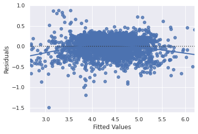

```python
sns.residplot(data=pred, x="Fitted Values", y="Residuals", lowess=True);
```

There's no exact pattern of this graph. Therefore, linearity and independence are satisfied

**Normality: Residuals are noramlly distributed**

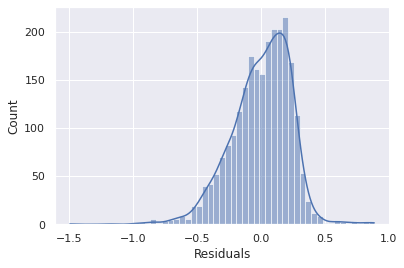

```python
sns.histplot(data=pred, x="Residuals", kde=True);
```

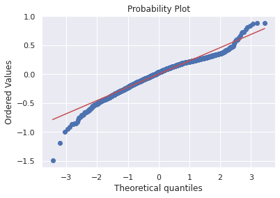

```python
import pylab
import scipy.stats as stats

stats.probplot(pred["Residuals"], dist="norm", plot=pylab);
```

```python
shapiro = stats.shapiro(pred["Residuals"])
print("Shapiro results:", shapiro)
```

```
Shapiro results: ShapiroResult(statistic=0.9690961837768555, pvalue=2.130726936518395e-22)
```

Shapiro results: ShapiroResult(statistic=0.9690961837768555, pvalue=2.130726936518395e-22)

**Homoscedasticity: Equal variance of residuals**

```python
import statsmodels.stats.api as sms
from statsmodels.compat import lzip

name = ["f statistic", "p value"]
test = sms.het_goldfeldquandt(pred["Residuals"], X_train3)
lzip(name, test)
```

```
[('f statistic', 1.043803594701024), ('p value', 0.22944475832470757)]
```

P-value is above 0.05, therefore we conclude that residuals are homoscedastic.

We can move on.

## Final Model

```python
final = sm.OLS(y_train, X_train3).fit()
print(final.summary())
```

```
                              OLS Regression Results
=================================================================================
Dep. Variable:     normalized_used_price   R-squared:                       0.842
Model:                               OLS   Adj. R-squared:                  0.842
Method:                    Least Squares   F-statistic:                     988.1
Date:                   Wed, 20 Jul 2022   Prob (F-statistic):               0.00
Time:                           19:18:04   Log-Likelihood:                 104.71
No. Observations:                   2417   AIC:                            -181.4
Df Residuals:                       2403   BIC:                            -100.4
Df Model:                             13
Covariance Type:               nonrobust
========================================================================================
                           coef    std err          t      P>|t|      [0.025      0.975]
----------------------------------------------------------------------------------------
const                  -38.9410      7.287     -5.344      0.000     -53.231     -24.651
screen_size              0.0256      0.003      7.764      0.000       0.019       0.032
main_camera_mp           0.0212      0.001     15.313      0.000       0.018       0.024
selfie_camera_mp         0.0140      0.001     13.203      0.000       0.012       0.016
ram                      0.0175      0.004      3.950      0.000       0.009       0.026
battery              -1.507e-05    7.1e-06     -2.122      0.034    -2.9e-05   -1.14e-06
weight                   0.0009      0.000      7.177      0.000       0.001       0.001
release_year             0.0199      0.004      5.516      0.000       0.013       0.027
normalized_new_price     0.4222      0.011     39.125      0.000       0.401       0.443
brand_name_Lenovo        0.0492      0.021      2.288      0.022       0.007       0.091
brand_name_Nokia         0.0675      0.031      2.203      0.028       0.007       0.128
brand_name_Xiaomi        0.0893      0.026      3.498      0.000       0.039       0.139
os_Others               -0.0704      0.030     -2.356      0.019      -0.129      -0.012
4g_yes                   0.0499      0.015      3.357      0.001       0.021       0.079
==============================================================================
Omnibus:                      232.847   Durbin-Watson:                   1.913
Prob(Omnibus):                  0.000   Jarque-Bera (JB):              458.097
Skew:                          -0.628   Prob(JB):                    3.35e-100
Kurtosis:                       4.724   Cond. No.                     6.02e+06
==============================================================================

Warnings:
[1] Standard Errors assume that the covariance matrix of the errors is correctly specified.
[2] The condition number is large, 6.02e+06. This might indicate that there are
strong multicollinearity or other numerical problems.
```